# Project : Classification, Regression, and Prediction

M1 Econometrics, Statistics, Economics & Magistere 2

Bana Nadège SABI DJESSOU Nercy Chancelle NISABWE Sètondji Hippolyte SODJINOU

2025-01-10

## Preliminaries

The data are from a website for cooking recipes. The company that owns the website wants to sell subscriptions, and the idea is that if the website receives lots of visits (so traffic is “high”) because of a posted recipe, the likelihood of a subscription sale increases.

Hence the overall objective of this project is to predict which recipes will lead to high traffic.

```r
options(repos = c(CRAN = "https://cran.rstudio.com/"))

if (!require(tidyverse))install.packages("tidyverse")

if (!require(gridExtra)) install.packages("gridExtra")

if (!require(stargazer)) install.packages("stargazer")

library(gridExtra) ## for: grid.arrange

library(stargazer)

library(tidyverse)
```

```r
data_traffic <- read_csv("recipe_site_traffic_2212 (1).csv")
glimpse(data_traffic)# displaying dataset
```

```
## Rows: 947
## Columns: 8
## $ recipe       <chr> "001", "002", "003", "004", "005", "006", "007", "008", "…
## $ calories     <dbl> NA, 35.48, 914.28, 97.03, 27.05, 691.15, 183.94, 299.14, …
## $ carbohydrate <dbl> NA, 38.56, 42.68, 30.56, 1.85, 3.46, 47.95, 3.17, 3.78, 4…
## $ sugar        <dbl> NA, 0.66, 3.09, 38.63, 0.80, 1.65, 9.75, 0.40, 3.37, 3.99…
## $ protein      <dbl> NA, 0.92, 2.88, 0.02, 0.53, 53.93, 46.71, 32.40, 3.79, 11…
## $ category     <chr> "Pork", "Potato", "Breakfast", "Beverages", "Beverages", …
## $ servings     <chr> "6", "4", "1", "4", "4", "2", "4", "4", "6", "2", "1", "6…
## $ high_traffic <chr> "High", "High", NA, "High", NA, "High", NA, NA, "High", N…
```

```r
str(data_traffic$servings) # Types of dataset
```

```
##  chr [1:947] "6" "4" "1" "4" "4" "2" "4" "4" "6" "2" "1" "6" "4" "4" "4" ...
```

```r
summary(data_traffic)
```

```
##     recipe             calories        carbohydrate         sugar
##  Length:947         Min.   :   0.14   Min.   :  0.030   Min.   :  0.010
##  Class :character   1st Qu.: 110.43   1st Qu.:  8.375   1st Qu.:  1.690
##  Mode  :character   Median : 288.55   Median : 21.480   Median :  4.550
##                     Mean   : 435.94   Mean   : 35.070   Mean   :  9.047
##                     3rd Qu.: 597.65   3rd Qu.: 44.965   3rd Qu.:  9.800
##                     Max.   :3633.16   Max.   :530.420   Max.   :148.750
##                     NA's   :52        NA's   :52        NA's   :52
##     protein          category           servings         high_traffic
##  Min.   :  0.000   Length:947         Length:947         Length:947
##  1st Qu.:  3.195   Class :character   Class :character   Class :character
##  Median : 10.800   Mode  :character   Mode  :character   Mode  :character
##  Mean   : 24.149
##  3rd Qu.: 30.200
##  Max.   :363.360
##  NA's   :52
```

## Recode the variables where necessary, and check the validity of the data.

```r
data_traffic <- data_traffic %>%
  mutate(servings = factor(servings)) %>%
  mutate(category = factor(category)) # code in factor

str(data_traffic)
```

```
## tibble [947 × 8] (S3: tbl_df/tbl/data.frame)
##  $ recipe      : chr [1:947] "001" "002" "003" "004" ...
##  $ calories    : num [1:947] NA 35.5 914.3 97 27.1 ...
##  $ carbohydrate: num [1:947] NA 38.56 42.68 30.56 1.85 ...
##  $ sugar       : num [1:947] NA 0.66 3.09 38.63 0.8 ...
##  $ protein     : num [1:947] NA 0.92 2.88 0.02 0.53 ...
##  $ category    : Factor w/ 11 levels "Beverages","Breakfast",..: 9 10 2 1 1 8 4 6 9 3 ...
##  $ servings    : Factor w/ 6 levels "1","2","4","4 as a snack",..: 5 3 1 3 3 2 3 3 5 2 ...
##  $ high_traffic: chr [1:947] "High" "High" NA "High" ...
```

```r
data_traffic_recode <- data_traffic %>%
  mutate(high_traffic = ifelse(high_traffic == "High", 1, NA)) %>%  ## recodage
  replace_na(list(high_traffic = 0))


data_traffic_recode
```

| recipe | calories | carbohydrate | sugar | protein | category | servings | high_traffic |
| --- | --- | --- | --- | --- | --- | --- | --- |
| 001 | NA | NA | NA | NA | Pork | 6 | 1 |
| 002 | 35.48 | 38.56 | 0.66 | 0.92 | Potato | 4 | 1 |
| 003 | 914.28 | 42.68 | 3.09 | 2.88 | Breakfast | 1 | 0 |
| 004 | 97.03 | 30.56 | 38.63 | 0.02 | Beverages | 4 | 1 |
| 005 | 27.05 | 1.85 | 0.80 | 0.53 | Beverages | 4 | 0 |
| 006 | 691.15 | 3.46 | 1.65 | 53.93 | One Dish Meal | 2 | 1 |
| 007 | 183.94 | 47.95 | 9.75 | 46.71 | Chicken Breast | 4 | 0 |
| 008 | 299.14 | 3.17 | 0.40 | 32.40 | Lunch/Snacks | 4 | 0 |
| 009 | 538.52 | 3.78 | 3.37 | 3.79 | Pork | 6 | 1 |
| 010 | 248.28 | 48.54 | 3.99 | 113.85 | Chicken | 2 | 0 |

[output cut: 937 more lines]

We will check the data quality and the impact of missing values. The following code calculates the proportion of missing values in the dataset and displays the columns that contain them along with their respective proportions.

```r
data_traffic_recode %>%
  summarise(across(everything() , ~ mean(is.na(.x) ) ) ) %>%
  dplyr::select(where(~ .x > 0))
```

| calories | carbohydrate | sugar | protein |
| --- | --- | --- | --- |
| 0.05491024 | 0.05491024 | 0.05491024 | 0.05491024 |

Now, let’s drop the missing values.

```r
data_traffic_recode_drop_na <- drop_na(data_traffic_recode) ## drop_na allows to drop missing values
data_traffic_recode_drop_na
```

| recipe | calories | carbohydrate | sugar | protein | category | servings | high_traffic |
| --- | --- | --- | --- | --- | --- | --- | --- |
| 002 | 35.48 | 38.56 | 0.66 | 0.92 | Potato | 4 | 1 |
| 003 | 914.28 | 42.68 | 3.09 | 2.88 | Breakfast | 1 | 0 |
| 004 | 97.03 | 30.56 | 38.63 | 0.02 | Beverages | 4 | 1 |
| 005 | 27.05 | 1.85 | 0.80 | 0.53 | Beverages | 4 | 0 |
| 006 | 691.15 | 3.46 | 1.65 | 53.93 | One Dish Meal | 2 | 1 |
| 007 | 183.94 | 47.95 | 9.75 | 46.71 | Chicken Breast | 4 | 0 |
| 008 | 299.14 | 3.17 | 0.40 | 32.40 | Lunch/Snacks | 4 | 0 |
| 009 | 538.52 | 3.78 | 3.37 | 3.79 | Pork | 6 | 1 |
| 010 | 248.28 | 48.54 | 3.99 | 113.85 | Chicken | 2 | 0 |
| 011 | 170.12 | 17.63 | 4.10 | 0.91 | Beverages | 1 | 0 |

[output cut: 885 more lines]

We are going to check the presence of missing values.

```r
data_traffic_recode_drop_na %>%
  summarise(across(everything() , ~ mean(is.na(.x) ) ) ) %>%
  dplyr::select(where(~ .x > 0))
```

Number of dropped observations.

```r
a = nrow(data_traffic_recode) # Number of observations in the dataset with missing values

b = nrow(data_traffic_recode_drop_na)# Number of observations in the dataset without missing values

a - b   #  Number of observations removed with missing values
```

```
## [1] 52
```

We have 52 observations that are removed out of 947.

```r
## sample selection induces no bias in outcomes
data_traffic_recode %>%
  count(high_traffic) %>%
  mutate(prop = n/sum(n)) ## proportion of outcome before dropped missing values
```

| high_traffic | n | prop |
| --- | --- | --- |
| 0 | 373 | 0.3938754 |
| 1 | 574 | 0.6061246 |

```r
data_traffic_recode_drop_na %>%
  count(high_traffic) %>%
  mutate(prop = n/sum(n))   ## proportion of outcome before dropped missing values
```

| high_traffic | n | prop |
| --- | --- | --- |
| 0 | 360 | 0.4022346 |
| 1 | 535 | 0.5977654 |

Since removing the missing values does not introduce any bias into the results, we will work with the new dataset without the missing values.

## 2- Exploratory Data Analysis (EDA)

```r
## bar plots for category

##Graphique en Barres pour les Catégories
p1 <- ggplot(data_traffic_recode_drop_na, aes(x = reorder(category, -high_traffic, FUN = mean), fill = as.factor(high_traffic))) +
  geom_bar(position = "fill", alpha = 0.8) +
  scale_fill_manual(
    values = c("#0073C2FF", "#EFC000FF"),  # Couleurs professionnelles
    name = "High Traffic",                # Titre de la légende
    labels = c("Low", "High")             # Libellés des catégories
  ) +
  labs(
    title = "High Traffic 's proportion by category",
    x = "Category",
    y = "Proportion"
  ) +
  coord_flip() +
  theme_minimal() +
  theme(
    plot.title = element_text(hjust = 0.5, size = 14, face = "bold"),  # Centrer et styliser le titre
    axis.text.x = element_text(size = 10),                            # Ajuster les tailles des textes
    axis.text.y = element_text(size = 10),
    legend.position = "top"                                           # Légende en haut
  )
```

```r
## bar plots for servings

p2 <- ggplot(data_traffic_recode_drop_na, aes(x = reorder(servings, -high_traffic, FUN = mean), fill = as.factor(high_traffic))) +
  geom_bar(position = "fill", alpha = 0.8) +
  scale_fill_manual(
    values = c("#0073C2FF", "#EFC000FF"),  # Professional Colors
    name = "High Traffic",                # Legend Title
    labels = c("Low", "High")             # Category Labels
  ) +
  labs(
    title = "High Traffic 's proportion by servings ",
    x = "servings",
    y = "Proportion"
  ) +
  coord_flip() +
  theme_minimal() +
  theme(
    plot.title = element_text(hjust = 0.5, size = 14, face = "bold"),  # Center and style the title
    axis.text.x = element_text(size = 10),                            # Adjust text sizes
    axis.text.y = element_text(size = 10),
    legend.position = "top"                                           # Legend at the top
  )
```

```r
## histogramme for protein

p3 <- data_traffic_recode_drop_na %>%
  ggplot(aes(x = protein, fill = factor(high_traffic))) +
  geom_histogram(alpha = 0.6, position = "stack", bins = 20) +
  geom_density(aes(y = after_stat(count)), alpha = 0.3, color = NA) +
  labs(
    title = "Protein Distribution by High Traffic",
    x = "protein",
    y = "Frequency",
    fill = "High Traffic"
  ) +
  theme_minimal() +
  theme(legend.position = "top") +
  scale_fill_manual(values = c("#0073C2FF", "#EFC000FF"))
```

```r
## histogramme for sugar

p4 <- data_traffic_recode_drop_na %>%
  ggplot(aes(x = sugar, fill = factor(high_traffic))) +
  geom_histogram(alpha = 0.6, position = "stack", bins = 20) +
  geom_density(aes(y = after_stat(count)), alpha = 0.3, color = NA) +
  labs(
    title = "Sugar Distribution by High Traffic",
    x = "sugar",
    y = "Frequency",
    fill = "High Traffic"
  ) +
  theme_minimal() +
  theme(legend.position = "top") +
  scale_fill_manual(values = c("#0073C2FF", "#EFC000FF"))
```

```r
## histogram for carbohydrate

p5 <- data_traffic_recode_drop_na %>%
  ggplot(aes(x = carbohydrate, fill = factor(high_traffic))) +
  geom_histogram(alpha = 0.6, position = "stack", bins = 20) +
  geom_density(aes(y = after_stat(count)), alpha = 0.3, color = NA) +
  labs(
    title = "Carbohydrate Distribution by High Traffic",
    x = "carbohydrate",
    y = "Frequency",
    fill = "High Traffic"
  ) +
  theme_minimal() +
  theme(legend.position = "top") +
  scale_fill_manual(values = c("#0073C2FF", "#EFC000FF"))
```

```r
## histogramme for calories

p6 <- data_traffic_recode_drop_na %>%
  ggplot(aes(x = calories, fill = factor(high_traffic))) +
  geom_histogram(alpha = 0.6, position = "stack", bins = 20) +
  geom_density(aes(y =after_stat(count)), alpha = 0.3, color = NA) +
  labs(
    title = "Calories Distribution by High Traffic",
    x = "calories",
    y = "Frequency",
    fill = "High Traffic"
  ) +
  theme_minimal() +
  theme(legend.position = "top") +
  scale_fill_manual(values = c("#0073C2FF", "#EFC000FF"))
```

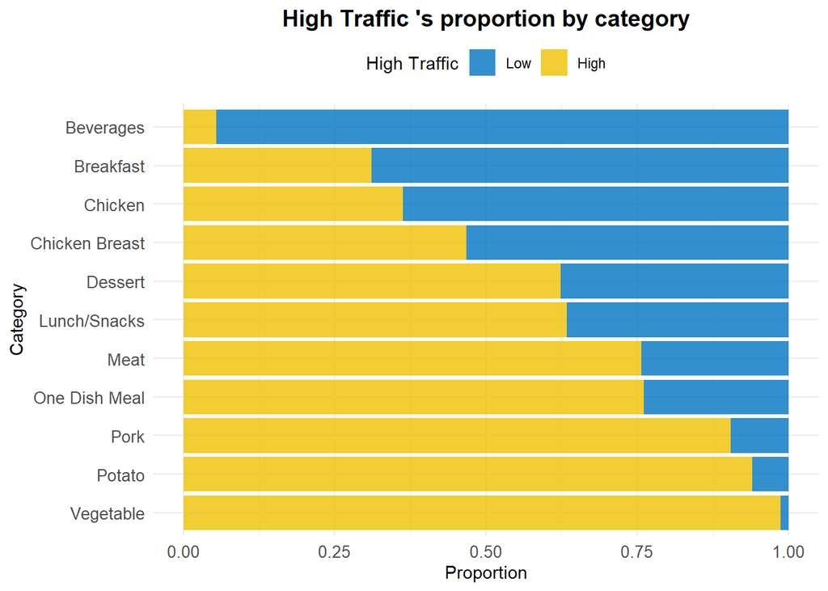

```r
## Displaying the results

p1
```

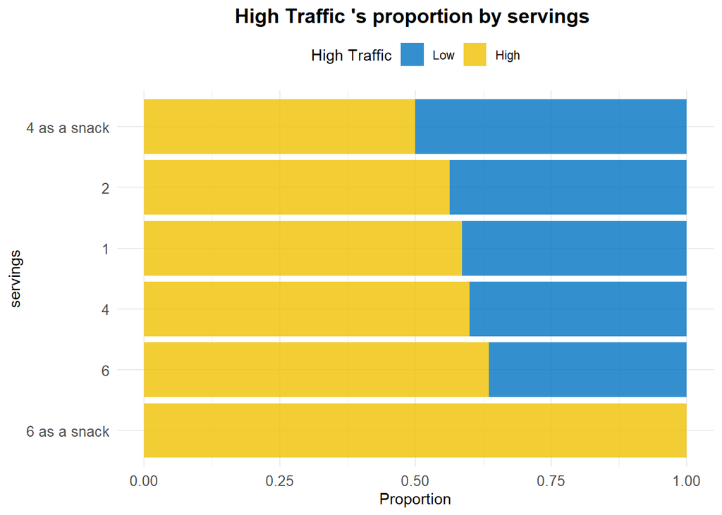

```r
p2
```

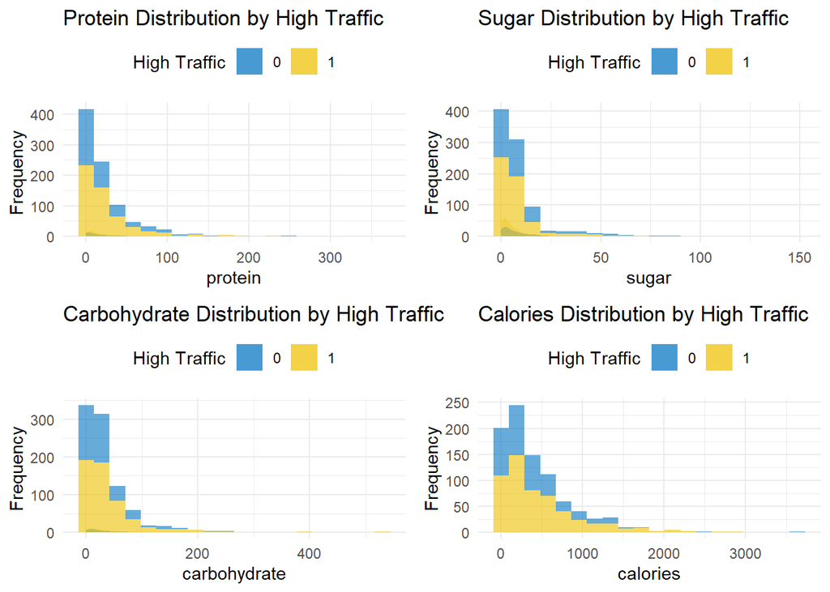

```r
grid.arrange(p3,p4,p5,p6, nrow=2)
```

## Splitting the data into training and test sets.

```r
set.seed(2453)
tr <- sample(nrow(data_traffic_recode_drop_na), round(nrow(data_traffic_recode_drop_na) * 0.6))  ## 60/40 split train/test
my_train_data <- data_traffic_recode_drop_na[tr, ] ## training sample
my_test_data  <- data_traffic_recode_drop_na[-tr, ]## test sample

my_train_data
```

| recipe | calories | carbohydrate | sugar | protein | category | servings | high_traffic |
| --- | --- | --- | --- | --- | --- | --- | --- |
| 517 | 264.13 | 39.05 | 2.97 | 23.04 | Chicken | 4 | 1 |
| 540 | 84.83 | 26.93 | 43.34 | 10.52 | Dessert | 6 | 0 |
| 131 | 190.52 | 2.57 | 0.56 | 1.58 | Beverages | 6 | 0 |
| 636 | 510.79 | 48.79 | 1.87 | 7.22 | Lunch/Snacks | 1 | 1 |
| 275 | 858.67 | 5.07 | 7.47 | 1.84 | Lunch/Snacks | 1 | 1 |
| 928 | 253.14 | 19.23 | 11.22 | 2.35 | One Dish Meal | 2 | 1 |
| 822 | 439.11 | 38.45 | 2.72 | 15.70 | Pork | 1 | 1 |
| 529 | 196.69 | 1.89 | 1.48 | 1.81 | Chicken Breast | 6 | 0 |
| 549 | 1440.69 | 30.59 | 5.78 | 30.63 | Lunch/Snacks | 6 as a snack | 1 |
| 774 | 597.75 | 34.77 | 4.70 | 38.26 | Chicken Breast | 1 | 1 |

[output cut: 527 more lines]

```r
my_test_data
```

| recipe | calories | carbohydrate | sugar | protein | category | servings | high_traffic |
| --- | --- | --- | --- | --- | --- | --- | --- |
| 002 | 35.48 | 38.56 | 0.66 | 0.92 | Potato | 4 | 1 |
| 009 | 538.52 | 3.78 | 3.37 | 3.79 | Pork | 6 | 1 |
| 010 | 248.28 | 48.54 | 3.99 | 113.85 | Chicken | 2 | 0 |
| 012 | 155.80 | 8.27 | 9.78 | 11.55 | Breakfast | 6 | 0 |
| 014 | 25.23 | 11.51 | 10.32 | 9.57 | Vegetable | 4 | 1 |
| 015 | 217.14 | 6.69 | 10.00 | 15.17 | Meat | 4 | 1 |
| 017 | 454.27 | 1.87 | 2.95 | 61.07 | Meat | 2 | 1 |
| 020 | 127.55 | 27.55 | 1.51 | 8.91 | Chicken | 2 | 0 |
| 025 | 1161.49 | 1.53 | 8.88 | 12.57 | Breakfast | 1 | 1 |
| 027 | 411.16 | 51.70 | 27.78 | 70.30 | Pork | 2 | 1 |

[output cut: 348 more lines]

```r
## Define the formula.
feature_set <- names(my_train_data)
feature_set <- feature_set[!(feature_set %in% c("recipe","high_traffic")) ]

modf <- formula(paste0("high_traffic ~ ", paste(feature_set, collapse="+"))) # define the model
modf
```

```
## high_traffic ~ calories + carbohydrate + sugar + protein + category +
##     servings
```

```r
summary(modf)
```

```
##  Length   Class    Mode
##       3 formula    call
```

## 4- Estimate a linear probability model (LPM) and a logit model

```r
## Define the formula.
feature_set <- names(my_train_data)
feature_set <- feature_set[!(feature_set %in% c("recipe","high_traffic")) ]

modf <- formula(paste0("high_traffic ~ ", paste(feature_set, collapse="+"))) # define the model
modf
```

```
## high_traffic ~ calories + carbohydrate + sugar + protein + category +
##     servings
```

Linear probability model (LPM)

```r
# Convert   high_traffic to numeric

 my_train_data$high_traffic <- as.numeric(as.character(my_train_data$high_traffic))

#Linear probability model (LPM) fit

lm.fit <- lm(modf , data=my_train_data )
summary(lm.fit)
```

```
##
## Call:
## lm(formula = modf, data = my_train_data)
##
## Residuals:
##      Min       1Q   Median       3Q      Max
## -0.97258 -0.30739  0.05599  0.27231  0.98072
##
## Coefficients:
##                          Estimate Std. Error t value Pr(>|t|)
## (Intercept)             6.712e-02  6.701e-02   1.002 0.316946
## calories               -3.057e-05  3.940e-05  -0.776 0.438240
## carbohydrate            3.485e-04  3.731e-04   0.934 0.350804
## sugar                  -1.192e-03  1.512e-03  -0.788 0.431130
## protein                 3.153e-04  6.538e-04   0.482 0.629763
## categoryBreakfast       2.403e-01  7.737e-02   3.105 0.002004 **
## categoryChicken         3.316e-01  8.964e-02   3.700 0.000239 ***
## categoryChicken Breast  4.167e-01  8.228e-02   5.064 5.71e-07 ***
## categoryDessert         6.518e-01  8.809e-02   7.400 5.57e-13 ***
## categoryLunch/Snacks    6.989e-01  8.317e-02   8.403 4.22e-16 ***
## categoryMeat            6.402e-01  8.535e-02   7.501 2.78e-13 ***
## categoryOne Dish Meal   6.883e-01  9.186e-02   7.494 2.93e-13 ***
## categoryPork            8.512e-01  9.523e-02   8.938  < 2e-16 ***
## categoryPotato          8.412e-01  8.311e-02  10.122  < 2e-16 ***
## categoryVegetable       9.106e-01  8.315e-02  10.951  < 2e-16 ***
## servings2               1.501e-02  5.836e-02   0.257 0.797119
## servings4              -9.499e-03  4.782e-02  -0.199 0.842621
## servings4 as a snack   -2.417e-01  2.947e-01  -0.820 0.412423
## servings6               2.585e-02  5.622e-02   0.460 0.645886
## servings6 as a snack    2.646e-01  4.116e-01   0.643 0.520597
## ---
## Signif. codes:  0 '***' 0.001 '**' 0.01 '*' 0.05 '.' 0.1 ' ' 1
##
## Residual standard error: 0.4044 on 517 degrees of freedom
## Multiple R-squared:  0.3376, Adjusted R-squared:  0.3133
## F-statistic: 13.87 on 19 and 517 DF,  p-value: < 2.2e-16
```

The discrete response Logit model is
$$E\{Y|X = x\} = \Pr\{Y = 1|X = x\} = G(\beta x)$$
where $G$ is the logistic distribution $G(z) = \frac{e^z}{1 + e^z}$.

```r
## A logit model
glm.fit <- glm(modf, data=my_train_data, family="binomial")
summary(glm.fit)
```

```
##
## Call:
## glm(formula = modf, family = "binomial", data = my_train_data)
##
## Coefficients:
##                          Estimate Std. Error z value Pr(>|z|)
## (Intercept)             -2.800588   0.638058  -4.389 1.14e-05 ***
## calories                -0.000177   0.000232  -0.763 0.445525
## carbohydrate             0.002719   0.002681   1.014 0.310421
## sugar                   -0.006839   0.008798  -0.777 0.436975
## protein                  0.001677   0.003749   0.447 0.654627
## categoryBreakfast        1.953657   0.665031   2.938 0.003307 **
## categoryChicken          2.366162   0.699969   3.380 0.000724 ***
## categoryChicken Breast   2.727279   0.674938   4.041 5.33e-05 ***
## categoryDessert          3.735893   0.715308   5.223 1.76e-07 ***
## categoryLunch/Snacks     3.970579   0.697898   5.689 1.28e-08 ***
## categoryMeat             3.679784   0.695140   5.294 1.20e-07 ***
## categoryOne Dish Meal    3.907939   0.734461   5.321 1.03e-07 ***
## categoryPork             5.187866   0.876548   5.919 3.25e-09 ***
## categoryPotato           5.182113   0.803754   6.447 1.14e-10 ***
## categoryVegetable        6.576955   1.176951   5.588 2.30e-08 ***
## servings2                0.086869   0.365941   0.237 0.812357
## servings4               -0.063203   0.293321  -0.215 0.829399
## servings4 as a snack    -1.054900   1.477123  -0.714 0.475129
## servings6                0.162923   0.348926   0.467 0.640553
## servings6 as a snack    12.556017 535.411357   0.023 0.981290
## ---
## Signif. codes:  0 '***' 0.001 '**' 0.01 '*' 0.05 '.' 0.1 ' ' 1
##
## (Dispersion parameter for binomial family taken to be 1)
##
##     Null deviance: 717.85  on 536  degrees of freedom
## Residual deviance: 510.51  on 517  degrees of freedom
## AIC: 550.51
##
## Number of Fisher Scoring iterations: 12
```

```r
## Displaying

stargazer(lm.fit,glm.fit,
          dep.var.caption="",dep.var.labels="",
          omit.table.layout = "n", star.cutoffs = NA,keep.stat=c("n"),no.space=TRUE,
          header=FALSE,
          column.labels=c("LPM", "Logit"),
          title="high traffic", type="text"
)
```

```
##
## high traffic
## ==========================================
##
##                           OLS    logistic
##                           LPM      Logit
##                           (1)       (2)
## ------------------------------------------
## calories               -0.00003   -0.0002
##                        (0.00004) (0.0002)
## carbohydrate            0.0003     0.003
##                        (0.0004)   (0.003)
## sugar                   -0.001    -0.007
##                         (0.002)   (0.009)
## protein                 0.0003     0.002
##                         (0.001)   (0.004)
## categoryBreakfast        0.240     1.954
##                         (0.077)   (0.665)
## categoryChicken          0.332     2.366
##                         (0.090)   (0.700)
## categoryChicken Breast   0.417     2.727
##                         (0.082)   (0.675)
## categoryDessert          0.652     3.736
##                         (0.088)   (0.715)
## categoryLunch/Snacks     0.699     3.971
##                         (0.083)   (0.698)
## categoryMeat             0.640     3.680
##                         (0.085)   (0.695)
## categoryOne Dish Meal    0.688     3.908
##                         (0.092)   (0.734)
## categoryPork             0.851     5.188
##                         (0.095)   (0.877)
## categoryPotato           0.841     5.182
##                         (0.083)   (0.804)
## categoryVegetable        0.911     6.577
##                         (0.083)   (1.177)
## servings2                0.015     0.087
##                         (0.058)   (0.366)
## servings4               -0.009    -0.063
##                         (0.048)   (0.293)
## servings4 as a snack    -0.242    -1.055
##                         (0.295)   (1.477)
## servings6                0.026     0.163
##                         (0.056)   (0.349)
## servings6 as a snack     0.265    12.556
##                         (0.412)  (535.411)
## Constant                 0.067    -2.801
##                         (0.067)   (0.638)
## ------------------------------------------
## Observations              537       537
## ==========================================
```

### Compare the marginal effects for the two models

In the linear model, the marginal effect is simply the respective coefficient, $\beta_k = \frac{dE\{Y|X=x\}}{dx_k}$. Since our GLM is non-linear, the marginal effect varies across individuals
$$\frac{dE\{Y|X = x\}}{dx_k} = \beta_k G'(\beta x)$$
with $G'(z) = e^z / (1 + e^z)^2$. In case the covariate $x_k$ is binary, the marginal effect is $G(\beta_0 + \ldots + \beta_{k-1} x_{k-1} + 1) - G(\beta_0 + \ldots + \beta_{k-1} x_{k-1} + 0)$. (You could also integrate the continuous marginal effect from 0 to 1 to get the same result.)

The sign of $\beta_k$ has a clear interpretation, but not its magnitude. Since the marginal effect is now a function of the covariates, it differs between different individuals, so is difficult to report. A pragmatic solution is to evaluate this function at the mean of the covariates $\beta \bar{x}$. This can be interpreted as the marginal effect for a notional reference individual (whose characteristics are equal to the sample mean). An alternative is to report the average marginal effect $\beta_k \frac{1}{n} \sum_i G'(\beta x_i)$.

```r
if (!require(mfx)) install.packages("mfx")

library(mfx)
```

```r
# Calculating marginal effects at the mean of the explanatory variables

eff_logit_atmean <- mfx::logitmfx(modf, data=my_train_data, atmean = TRUE)
eff_logit_atmean
```

```
## Call:
## mfx::logitmfx(formula = modf, data = my_train_data, atmean = TRUE)
##
## Marginal Effects:
##                              dF/dx   Std. Err.       z   P>|z|
## calories               -3.9702e-05  5.3564e-05 -0.7412 0.45857
## carbohydrate            6.0999e-04  6.3150e-04  0.9659 0.33408
## sugar                  -1.5343e-03  2.0344e-03 -0.7541 0.45077
## protein                 3.7622e-04  8.4957e-04  0.4428 0.65788
## categoryBreakfast       3.0775e-01  1.7708e-01  1.7379 0.08224 .
## categoryChicken         3.2594e-01  1.9289e-01  1.6898 0.09106 .
## categoryChicken Breast  3.7154e-01  2.0866e-01  1.7806 0.07499 .
## categoryDessert         3.9821e-01  2.3048e-01  1.7278 0.08403 .
## categoryLunch/Snacks    4.1309e-01  2.3490e-01  1.7585 0.07865 .
## categoryMeat            4.0392e-01  2.3051e-01  1.7523 0.07973 .
## categoryOne Dish Meal   3.9088e-01  2.3104e-01  1.6918 0.09069 .
## categoryPork            4.1523e-01  2.4211e-01  1.7150 0.08634 .
## categoryPotato          4.5478e-01  2.4679e-01  1.8428 0.06536 .
## categoryVegetable       4.7057e-01  2.5007e-01  1.8817 0.05987 .
## servings2               1.9306e-02  8.0790e-02  0.2390 0.81113
## servings4              -1.4198e-02  6.6131e-02 -0.2147 0.83001
## servings4 as a snack   -2.5659e-01  3.5608e-01 -0.7206 0.47115
## servings6               3.5935e-02  7.6573e-02  0.4693 0.63886
## servings6 as a snack    3.4510e-01  3.2653e-02 10.5686 < 2e-16 ***
## ---
## Signif. codes:  0 '***' 0.001 '**' 0.01 '*' 0.05 '.' 0.1 ' ' 1
##
## dF/dx is for discrete change for the following variables:
##
##  [1] "categoryBreakfast"      "categoryChicken"        "categoryChicken Breast"
##  [4] "categoryDessert"        "categoryLunch/Snacks"   "categoryMeat"
##  [7] "categoryOne Dish Meal"  "categoryPork"           "categoryPotato"
## [10] "categoryVegetable"      "servings2"              "servings4"
## [13] "servings4 as a snack"   "servings6"              "servings6 as a snack"
```

```r
# Calculating average marginal effects for each explanatory variable

eff_logit_average <- mfx::logitmfx(modf, data=my_train_data, atmean = FALSE) #average ME
eff_logit_average
```

```
## Call:
## mfx::logitmfx(formula = modf, data = my_train_data, atmean = FALSE)
##
## Marginal Effects:
##                              dF/dx   Std. Err.       z     P>|z|
## calories               -2.7827e-05  3.6603e-05 -0.7602    0.4471
## carbohydrate            4.2755e-04  4.2388e-04  1.0086    0.3131
## sugar                  -1.0754e-03  1.3885e-03 -0.7745    0.4386
## protein                 2.6369e-04  5.9021e-04  0.4468    0.6550
## categoryBreakfast       2.1778e-01  4.2948e-02  5.0708 3.962e-07 ***
## categoryChicken         2.6228e-01  4.2403e-02  6.1854 6.194e-10 ***
## categoryChicken Breast  2.9316e-01  3.5752e-02  8.1999 2.407e-16 ***
## categoryDessert         3.7387e-01  2.7472e-02 13.6092 < 2.2e-16 ***
## categoryLunch/Snacks    3.9369e-01  2.5359e-02 15.5245 < 2.2e-16 ***
## categoryMeat            3.7663e-01  2.7657e-02 13.6182 < 2.2e-16 ***
## categoryOne Dish Meal   3.8307e-01  2.6778e-02 14.3057 < 2.2e-16 ***
## categoryPork            4.2671e-01  2.0764e-02 20.5508 < 2.2e-16 ***
## categoryPotato          4.5180e-01  2.1014e-02 21.5002 < 2.2e-16 ***
## categoryVegetable       4.6101e-01  1.8567e-02 24.8298 < 2.2e-16 ***
## servings2               1.3611e-02  5.7112e-02  0.2383    0.8116
## servings4              -9.9508e-03  4.6230e-02 -0.2152    0.8296
## servings4 as a snack   -1.7237e-01  2.4118e-01 -0.7147    0.4748
## servings6               2.5441e-02  5.4049e-02  0.4707    0.6378
## servings6 as a snack    3.8969e-01  1.7769e-02 21.9309 < 2.2e-16 ***
## ---
## Signif. codes:  0 '***' 0.001 '**' 0.01 '*' 0.05 '.' 0.1 ' ' 1
##
## dF/dx is for discrete change for the following variables:
##
##  [1] "categoryBreakfast"      "categoryChicken"        "categoryChicken Breast"
##  [4] "categoryDessert"        "categoryLunch/Snacks"   "categoryMeat"
##  [7] "categoryOne Dish Meal"  "categoryPork"           "categoryPotato"
## [10] "categoryVegetable"      "servings2"              "servings4"
## [13] "servings4 as a snack"   "servings6"              "servings6 as a snack"
```

```r
# comparison
ME <- cbind(eff_logit_atmean$mfxest[,"dF/dx"],
            eff_logit_average$mfxest[,"dF/dx"],
            coefficients(lm.fit)[-1])
colnames(ME) <- c("ref person", "average", "LPM coef")
print(ME, digits=3)
```

```
##                        ref person   average  LPM coef
## calories                -3.97e-05 -2.78e-05 -3.06e-05
## carbohydrate             6.10e-04  4.28e-04  3.48e-04
## sugar                   -1.53e-03 -1.08e-03 -1.19e-03
## protein                  3.76e-04  2.64e-04  3.15e-04
## categoryBreakfast        3.08e-01  2.18e-01  2.40e-01
## categoryChicken          3.26e-01  2.62e-01  3.32e-01
## categoryChicken Breast   3.72e-01  2.93e-01  4.17e-01
## categoryDessert          3.98e-01  3.74e-01  6.52e-01
## categoryLunch/Snacks     4.13e-01  3.94e-01  6.99e-01
## categoryMeat             4.04e-01  3.77e-01  6.40e-01
## categoryOne Dish Meal    3.91e-01  3.83e-01  6.88e-01
## categoryPork             4.15e-01  4.27e-01  8.51e-01
## categoryPotato           4.55e-01  4.52e-01  8.41e-01
## categoryVegetable        4.71e-01  4.61e-01  9.11e-01
## servings2                1.93e-02  1.36e-02  1.50e-02
## servings4               -1.42e-02 -9.95e-03 -9.50e-03
## servings4 as a snack    -2.57e-01 -1.72e-01 -2.42e-01
## servings6                3.59e-02  2.54e-02  2.58e-02
## servings6 as a snack     3.45e-01  3.90e-01  2.65e-01
```

### The t-statistics of the estimated marginal effects

### Assessment of the Importance of Variables

```r
# Extraction of t-Statistics for Marginal Effects of the LPM
summary(lm.fit)
```

```
##
## Call:
## lm(formula = modf, data = my_train_data)
##
## Residuals:
##      Min       1Q   Median       3Q      Max
## -0.97258 -0.30739  0.05599  0.27231  0.98072
##
## Coefficients:
##                          Estimate Std. Error t value Pr(>|t|)
## (Intercept)             6.712e-02  6.701e-02   1.002 0.316946
## calories               -3.057e-05  3.940e-05  -0.776 0.438240
## carbohydrate            3.485e-04  3.731e-04   0.934 0.350804
## sugar                  -1.192e-03  1.512e-03  -0.788 0.431130
## protein                 3.153e-04  6.538e-04   0.482 0.629763
## categoryBreakfast       2.403e-01  7.737e-02   3.105 0.002004 **
## categoryChicken         3.316e-01  8.964e-02   3.700 0.000239 ***
## categoryChicken Breast  4.167e-01  8.228e-02   5.064 5.71e-07 ***
## categoryDessert         6.518e-01  8.809e-02   7.400 5.57e-13 ***
## categoryLunch/Snacks    6.989e-01  8.317e-02   8.403 4.22e-16 ***
## categoryMeat            6.402e-01  8.535e-02   7.501 2.78e-13 ***
## categoryOne Dish Meal   6.883e-01  9.186e-02   7.494 2.93e-13 ***
## categoryPork            8.512e-01  9.523e-02   8.938  < 2e-16 ***
## categoryPotato          8.412e-01  8.311e-02  10.122  < 2e-16 ***
## categoryVegetable       9.106e-01  8.315e-02  10.951  < 2e-16 ***
## servings2               1.501e-02  5.836e-02   0.257 0.797119
## servings4              -9.499e-03  4.782e-02  -0.199 0.842621
## servings4 as a snack   -2.417e-01  2.947e-01  -0.820 0.412423
## servings6               2.585e-02  5.622e-02   0.460 0.645886
## servings6 as a snack    2.646e-01  4.116e-01   0.643 0.520597
## ---
## Signif. codes:  0 '***' 0.001 '**' 0.01 '*' 0.05 '.' 0.1 ' ' 1
##
## Residual standard error: 0.4044 on 517 degrees of freedom
## Multiple R-squared:  0.3376, Adjusted R-squared:  0.3133
## F-statistic: 13.87 on 19 and 517 DF,  p-value: < 2.2e-16
```

```r
# variable importance: t-statistic
temp_lpm <- summary(lm.fit) # get t-statistic

varimp_lpm <- tibble(variable=rownames(temp_lpm$coefficients[-1,]), # drop Intercept
                 score_lpm =temp_lpm$coefficients[-1,3]) %>%
  arrange(desc(abs(score_lpm))) %>%
  # set levels as otherwise factors generated alphabetically in ggplot
  mutate(variable=factor(variable, levels=variable[order(abs(score_lpm))]))
varimp_lpm
```

| variable | score_lpm |
| --- | --- |
| categoryVegetable | 10.9511571 |
| categoryPotato | 10.1215621 |
| categoryPork | 8.9379198 |
| categoryLunch/Snacks | 8.4033668 |
| categoryMeat | 7.5008976 |
| categoryOne Dish Meal | 7.4935277 |
| categoryDessert | 7.3995041 |
| categoryChicken Breast | 5.0642391 |
| categoryChicken | 3.6996900 |
| categoryBreakfast | 3.1054119 |

[output cut: 9 more lines]

```r
# Extraction of z-Statistics for Marginal Effects of the Logit Model

summary(glm.fit)
```

```
##
## Call:
## glm(formula = modf, family = "binomial", data = my_train_data)
##
## Coefficients:
##                          Estimate Std. Error z value Pr(>|z|)
## (Intercept)             -2.800588   0.638058  -4.389 1.14e-05 ***
## calories                -0.000177   0.000232  -0.763 0.445525
## carbohydrate             0.002719   0.002681   1.014 0.310421
## sugar                   -0.006839   0.008798  -0.777 0.436975
## protein                  0.001677   0.003749   0.447 0.654627
## categoryBreakfast        1.953657   0.665031   2.938 0.003307 **
## categoryChicken          2.366162   0.699969   3.380 0.000724 ***
## categoryChicken Breast   2.727279   0.674938   4.041 5.33e-05 ***
## categoryDessert          3.735893   0.715308   5.223 1.76e-07 ***
## categoryLunch/Snacks     3.970579   0.697898   5.689 1.28e-08 ***
## categoryMeat             3.679784   0.695140   5.294 1.20e-07 ***
## categoryOne Dish Meal    3.907939   0.734461   5.321 1.03e-07 ***
## categoryPork             5.187866   0.876548   5.919 3.25e-09 ***
## categoryPotato           5.182113   0.803754   6.447 1.14e-10 ***
## categoryVegetable        6.576955   1.176951   5.588 2.30e-08 ***
## servings2                0.086869   0.365941   0.237 0.812357
## servings4               -0.063203   0.293321  -0.215 0.829399
## servings4 as a snack    -1.054900   1.477123  -0.714 0.475129
## servings6                0.162923   0.348926   0.467 0.640553
## servings6 as a snack    12.556017 535.411357   0.023 0.981290
## ---
## Signif. codes:  0 '***' 0.001 '**' 0.01 '*' 0.05 '.' 0.1 ' ' 1
##
## (Dispersion parameter for binomial family taken to be 1)
##
##     Null deviance: 717.85  on 536  degrees of freedom
## Residual deviance: 510.51  on 517  degrees of freedom
## AIC: 550.51
##
## Number of Fisher Scoring iterations: 12
```

```r
#  variable importance: t-statistic
temp_logt <- summary(glm.fit) # get t-statistic

varimp_logt <- tibble(variable=rownames(temp_logt$coefficients[-1,]), # drop Intercept
                     score_logt =temp_logt$coefficients[-1,3]) %>%
  arrange(desc(abs(score_logt))) %>%
  # set levels as otherwise factors generated alphabetically in ggplot
  mutate(variable=factor(variable, levels=variable[order(abs(score_logt))]))
varimp_logt
```

| variable | score_logt |
| --- | --- |
| categoryPotato | 6.44738702 |
| categoryPork | 5.91851911 |
| categoryLunch/Snacks | 5.68934099 |
| categoryVegetable | 5.58812932 |
| categoryOne Dish Meal | 5.32082893 |
| categoryMeat | 5.29358890 |
| categoryDessert | 5.22277242 |
| categoryChicken Breast | 4.04078591 |
| categoryChicken | 3.38038142 |
| categoryBreakfast | 2.93769478 |

[output cut: 9 more lines]

### Column plot for LPM variable importance score

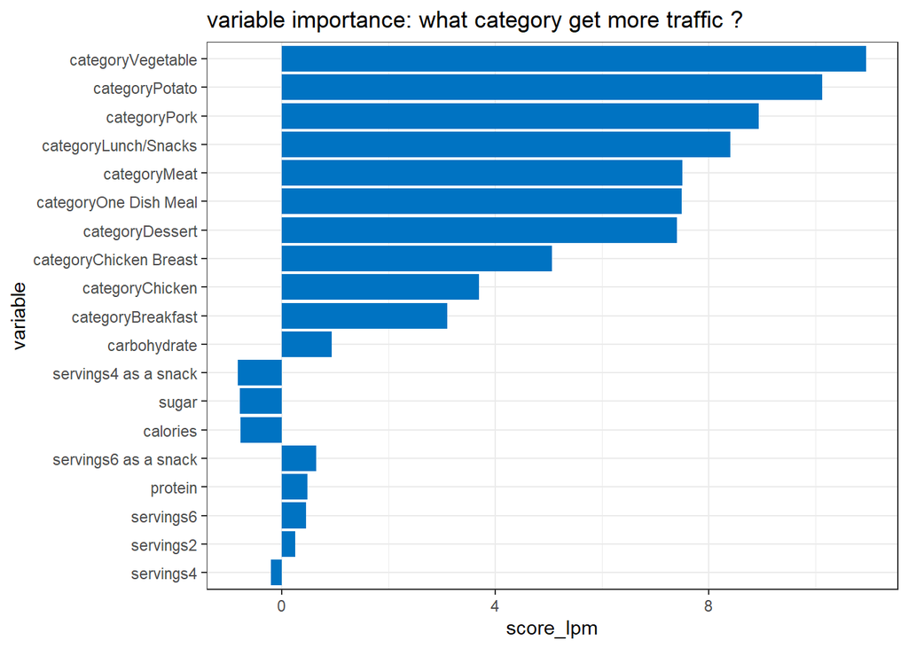

```r
ggplot(varimp_lpm, aes(x=variable, y=score_lpm )) +
  geom_col(fill = "#0073C2FF") +
  coord_flip() +
  theme_bw() +
  ggtitle("variable importance: what category get more traffic ?")
```

### Column plot for Logit variable importance score

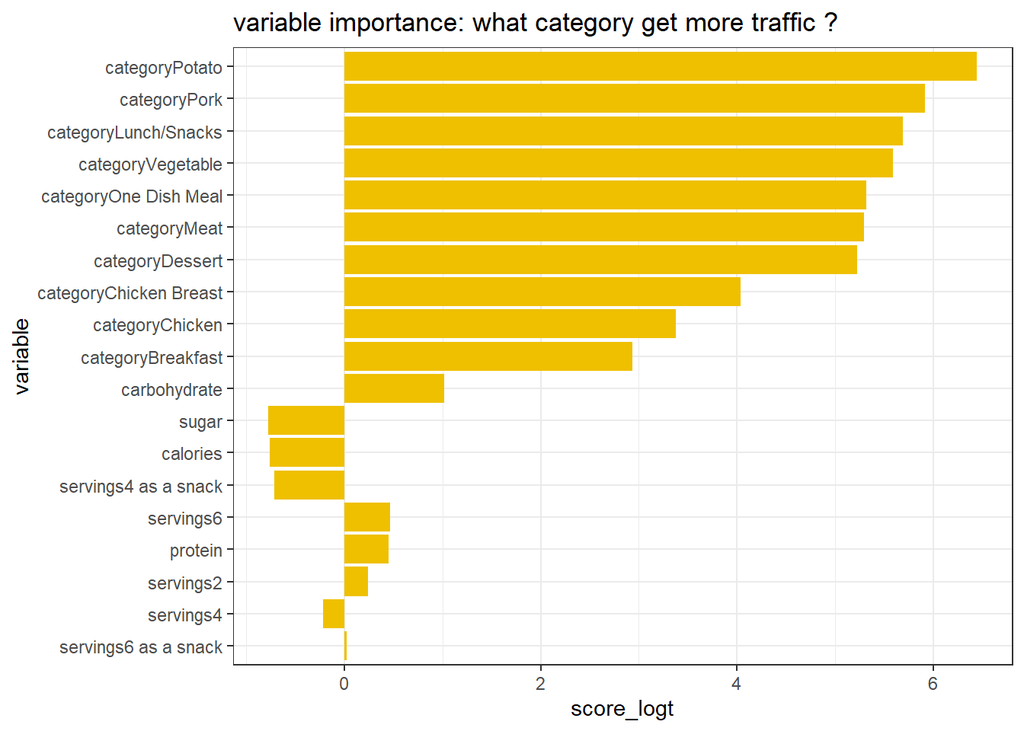

```r
ggplot(varimp_logt, aes(x=variable, y=score_logt )) +
  geom_col( fill = "#EFC000FF") +
  coord_flip() +
  theme_bw() +
  ggtitle("variable importance: what category get more traffic ?")
```

```r
# combine into one dataset

var_cbine <- left_join ( varimp_lpm, varimp_logt)
var_cbine
```

| variable | score_lpm | score_logt |
| --- | --- | --- |
| categoryVegetable | 10.9511571 | 5.58812932 |
| categoryPotato | 10.1215621 | 6.44738702 |
| categoryPork | 8.9379198 | 5.91851911 |
| categoryLunch/Snacks | 8.4033668 | 5.68934099 |
| categoryMeat | 7.5008976 | 5.29358890 |
| categoryOne Dish Meal | 7.4935277 | 5.32082893 |
| categoryDessert | 7.3995041 | 5.22277242 |
| categoryChicken Breast | 5.0642391 | 4.04078591 |
| categoryChicken | 3.6996900 | 3.38038142 |
| categoryBreakfast | 3.1054119 | 2.93769478 |

[output cut: 9 more lines]

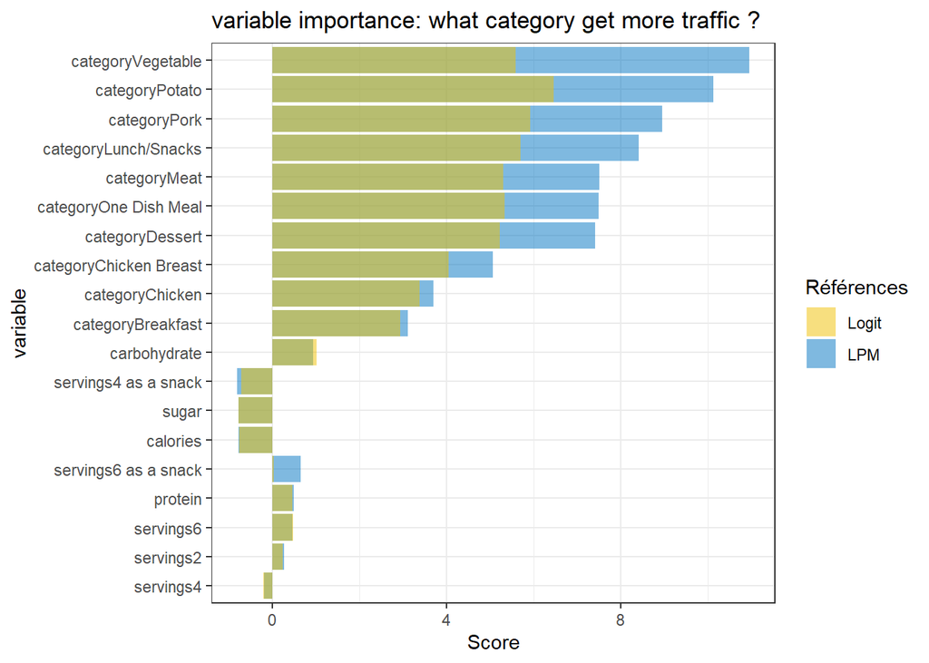

```r
# Column plot

ggplot() +
  geom_col(data = var_cbine, aes(x = variable, y = score_lpm, fill = "LPM"), alpha = 0.5) +
  geom_col(data = var_cbine, aes(x = variable, y = score_logt, fill = "Logit"), alpha = 0.5) +
  scale_fill_manual(values = c("LPM" = "#0073C2FF", "Logit" = "#EFC000FF"),
                    name = "Références") +
  coord_flip() +
  labs(y = "Score", title = "variable importance: what category get more traffic ?") +
  theme(axis.text.x = element_text(angle = 90, hjust = 1)) +
  theme_bw()
```

The categories **Vegetable**, **Potato**, **Pork**, and **Lunch/Snacks** stand out as the categories with the greatest impact on recipe traffic, with high scores in both models (Logit and LPM). However, the **Vegetable** category appears to be the most significant in the linear probability model, while in the Logit model, the **Potato** category takes the lead.

**One Dish Meal**, **Meat**, and **Dessert** also have a notable but slightly lower impact. This suggests that they contribute significantly but not as much as vegetables or potatoes.

Thus, vegetables, potatoes, and pork, often served for Lunch or as Snacks (Lunch/Snacks category), bring the most traffic to the company.

## Estimate a Random Forest (RF) model

### Before estimating a Random Forest model, let exam an individual tree in order to understand better the RF.

```r
if (!require(rpart)) install.packages("rpart")
if (!require(rpart.plot)) install.packages("rpart.plot")
library(rpart)
library(rpart.plot)
```

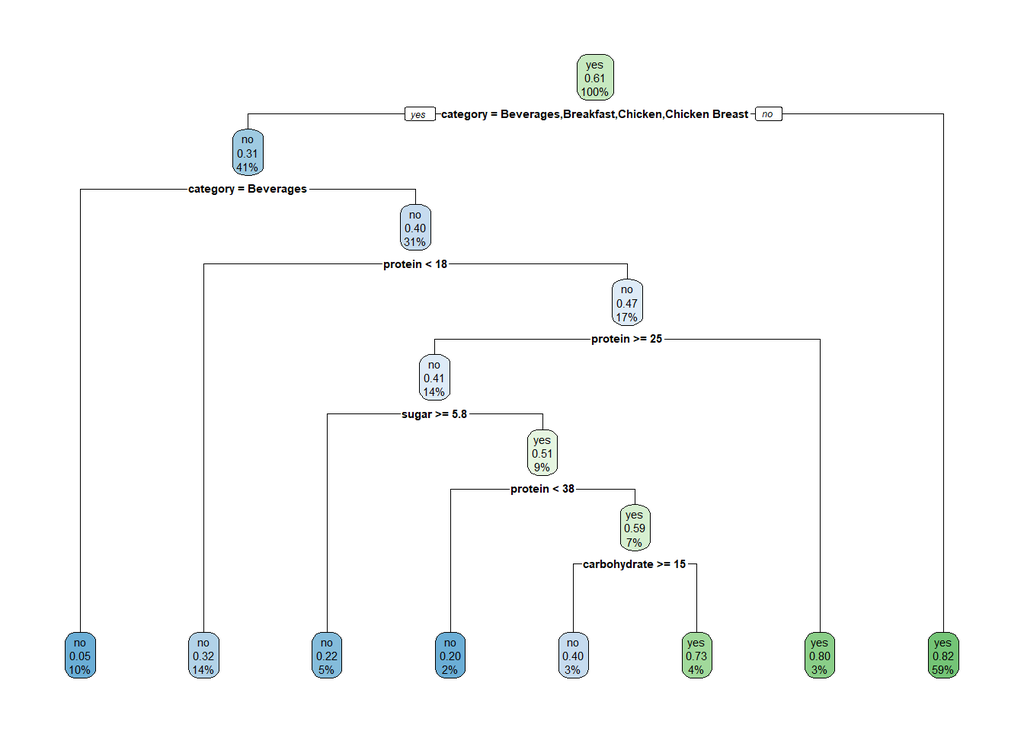

```r
# Converting the target variable, high_traffic into a factor.
my_train_data %>% mutate(high_traffic = factor(high_traffic,labels = c("no","yes") )) -> my_train_data_f


trafficfit <- rpart(modf,data=my_train_data_f,method="class")
rpart.plot(trafficfit)
```

```r
trafficfit$cptable[, c("CP", "nsplit")]
```

```
##           CP nsplit
## 1 0.39234450      0
## 2 0.01435407      1
## 3 0.01000000      7
```

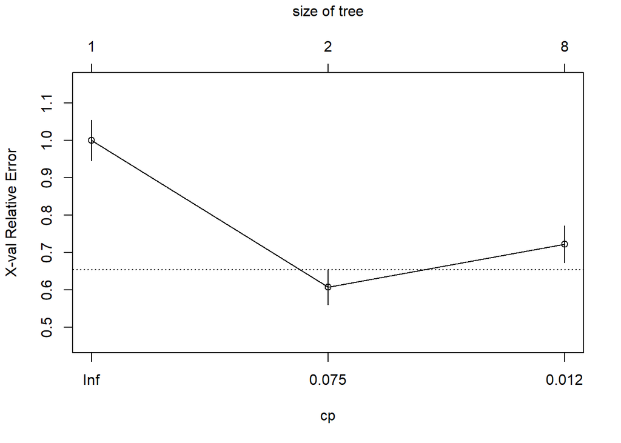

```r
rpart::plotcp(trafficfit)
```

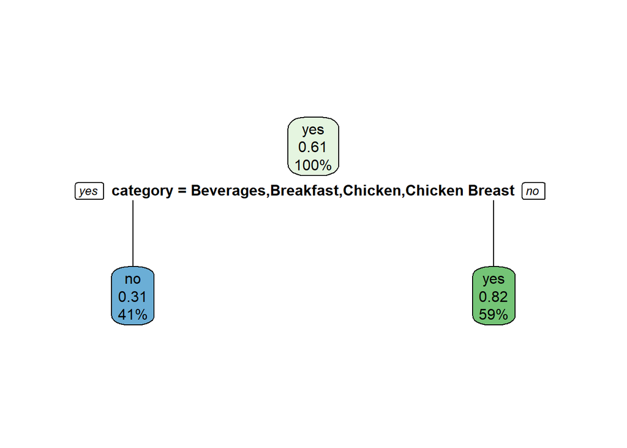

```r
# Find  CP optimal
optimal_cp <- trafficfit$cptable[which.min(trafficfit$cptable[, "xerror"]), "CP"]

# Pruning the tree using CP optimal

trafficfit_pruned <- prune(trafficfit, cp = optimal_cp)

rpart.plot(trafficfit_pruned)
```

### Random Forest (FR)

We will use the 10-fold CV

```r
if (!require(caret)) install.packages("caret")
if (!require(ranger)) install.packages("ranger")

library(ranger)
library(caret)
```

```r
cores <- parallel::detectCores() ## for use in: `ranger::ranger` (parallel mode)
```

```r
control <- trainControl(method="cv", number=10) # 10-fold CV using caret
```

```r
myGrid <- expand.grid(mtry = 2:6,
             splitrule = "gini",
             min.node.size = 1) # Minimal node size; default 1 for classification

metric <- "Accuracy"

set.seed(345)

# for speed:  `ranger` in parallel mode
fit.rf_cv <- train(modf, data=my_train_data_f, method="ranger",
                   metric=metric, trControl=control,
                   tuneGrid = myGrid, num.threads = cores)
```

```r
print(fit.rf_cv)
```

```
## Random Forest
##
## 537 samples
##   6 predictor
##   2 classes: 'no', 'yes'
##
## No pre-processing
## Resampling: Cross-Validated (10 fold)
## Summary of sample sizes: 483, 483, 483, 484, 484, 483, ...
## Resampling results across tuning parameters:
##
##   mtry  Accuracy   Kappa
##   2     0.7185884  0.3747100
##   3     0.7333683  0.4251243
##   4     0.7204053  0.4003118
##   5     0.7184486  0.3940107
##   6     0.7091894  0.3722248
##
## Tuning parameter 'splitrule' was held constant at a value of gini
##
## Tuning parameter 'min.node.size' was held constant at a value of 1
## Accuracy was used to select the optimal model using the largest value.
## The final values used for the model were mtry = 3, splitrule = gini
##  and min.node.size = 1.
```

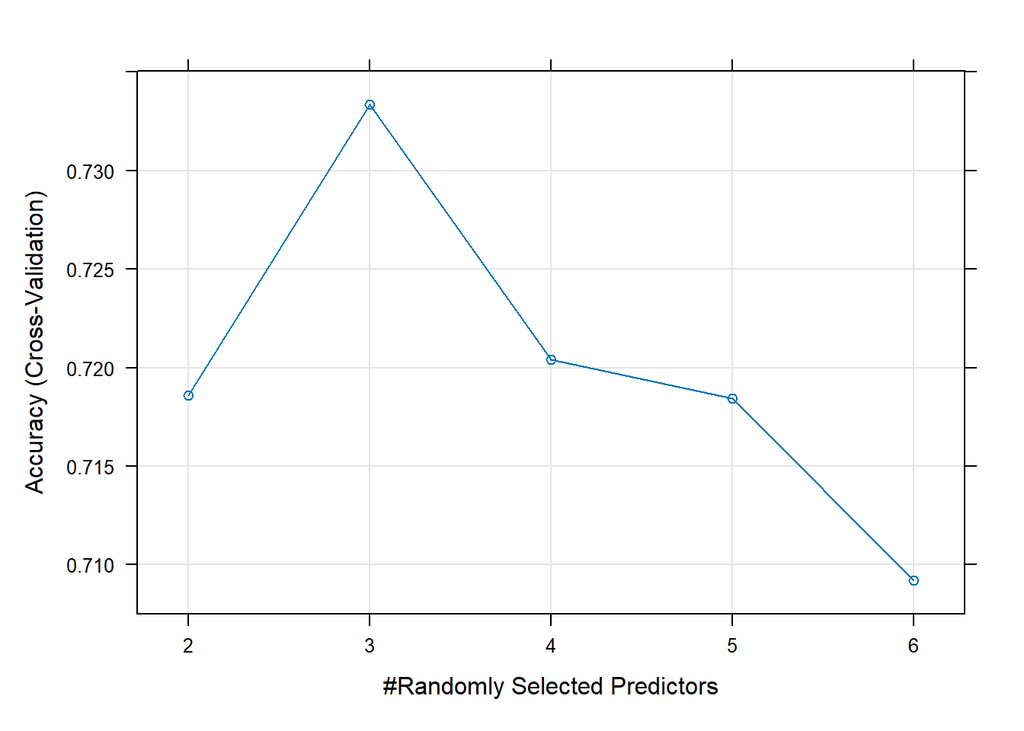

```r
plot(fit.rf_cv)
```

```r
fit.rf_cv$resample
```

| Accuracy | Kappa | Resample |
| --- | --- | --- |
| 0.7222222 | 0.4104803 | Fold03 |
| 0.7962963 | 0.5600000 | Fold09 |
| 0.6981132 | 0.3312303 | Fold04 |
| 0.7962963 | 0.5676856 | Fold06 |
| 0.7777778 | 0.5242291 | Fold01 |
| 0.7777778 | 0.5242291 | Fold02 |
| 0.6792453 | 0.2632870 | Fold10 |
| 0.6415094 | 0.2568266 | Fold05 |
| 0.7962963 | 0.5600000 | Fold07 |
| 0.6481481 | 0.2532751 | Fold08 |

```r
fit.rf_cv$bestTune
```

|  | mtry | splitrule | min.node.size |
| --- | --- | --- | --- |
| 2 | 3 | gini | 1 |

```r
fit.rf_cv$finalModel
```

```
## Ranger result
##
## Call:
##  ranger::ranger(dependent.variable.name = ".outcome", data = x,      mtry = min(param$mtry, ncol(x)), min.node.size = param$min.node.size,      splitrule = as.character(param$splitrule), write.forest = TRUE,      probability = classProbs, ...)
##
## Type:                             Classification
## Number of trees:                  500
## Sample size:                      537
## Number of independent variables:  19
## Mtry:                             3
## Target node size:                 1
## Variable importance mode:         none
## Splitrule:                        gini
## OOB prediction error:             27.37 %
```

### Fit the best model

```r
## fit the best RF model (in terms of CV performance) to train data
set.seed(345)
rf.fit2 <- ranger::ranger(modf, data=my_train_data_f, mtry=fit.rf_cv$bestTune$mtry,
                  importance="impurity",probability = TRUE)

print(rf.fit2)
```

```
## Ranger result
##
## Call:
##  ranger::ranger(modf, data = my_train_data_f, mtry = fit.rf_cv$bestTune$mtry,      importance = "impurity", probability = TRUE)
##
## Type:                             Probability estimation
## Number of trees:                  500
## Sample size:                      537
## Number of independent variables:  6
## Mtry:                             3
## Target node size:                 10
## Variable importance mode:         impurity
## Splitrule:                        gini
## OOB prediction error (Brier s.):  0.1765468
```

### The variable importance scores

```r
varimp_rf <- tibble(Variable=names(rf.fit2$variable.importance),
                 Importance = rf.fit2$variable.importance) %>%
    arrange(desc(Importance)) %>%
    mutate(Variable=factor(Variable, levels=Variable[order(Importance)]))
print(varimp_rf)
```

```
## # A tibble: 6 × 2
##   Variable     Importance
##   <fct>             <dbl>
## 1 category          74.6
## 2 protein           37.9
## 3 calories          32.5
## 4 sugar             30.5
## 5 carbohydrate      25.0
## 6 servings           6.47
```

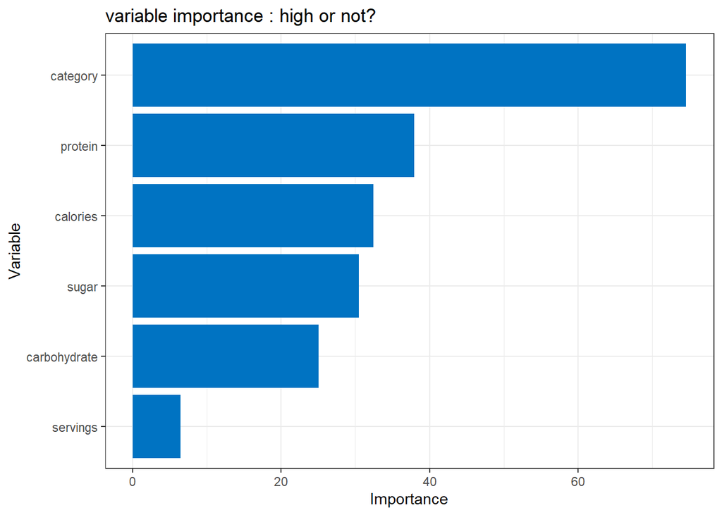

```r
ggplot(varimp_rf,aes(Variable, Importance)) +
  geom_col(fill = "#0073C2FF") +
  coord_flip() +
  labs(x="Variable", y="Importance", title="variable importance : high or not?") +
  theme_bw()
```

This graph indicates that the category variable is the most important for the model compared to the other variables, although protein and calories should not be overlooked either. To predict high traffic on a recipe, the category is by far the most important factor, followed by nutritional elements such as protein and calories.

### Prediction using your models (LPM, Logit, RF) and the test data

```r
# LPM prediction over text data
data_check = my_test_data

my_test_data$prob_lpm <- predict(lm.fit, my_test_data)
my_test_data$class_lpm <- ifelse(my_test_data$prob_lpm > .5, 1,0)
```

```r
# Logit prediction over text data

my_test_data$prob_logit <- predict(glm.fit, my_test_data, type = "response") # prediction for each observation into datset
my_test_data$class_logit <- ifelse(my_test_data$prob_logit > .5, 1,0)
```

```r
# RF prediction over text data
my_test_data$prob_rf <- predict(rf.fit2, my_test_data, type = "response")$predictions[,2]
my_test_data$class_rf <- ifelse(my_test_data$prob_rf > 0.5, 1, 0)
```

### Performance of the models with Confusion Matrix

```r
library(dplyr)

# LPM
my_test_data %>%
  dplyr::select(high_traffic, class_lpm, prob_lpm) %>%
  mutate( high_traffic = factor(high_traffic,levels=c(0,1),
                            labels = c("Not High","High")),
          class_lpm  = factor(class_lpm,levels=c(0,1),
                            labels = c("Not High","High"))
          ) -> preds_lpm
```

Confusion Matrix of LPM

```r
# Confusion Matrix

cm_lpm_caret <- caret::confusionMatrix(preds_lpm$class_lpm, preds_lpm$high_traffic)
 cm_lpm = cm_lpm_caret$table
prop.table(cm_lpm,margin =1)
```

```
##           Reference
## Prediction  Not High      High
##   Not High 0.7519380 0.2480620
##   High     0.2358079 0.7641921
```

```r
# retrieve results from `cm_lpm_caret`
c(cm_lpm_caret$overall["Accuracy"],cm_lpm_caret$byClass["Sensitivity"],
  cm_lpm_caret$byClass["Specificity"] )
```

```
##    Accuracy Sensitivity Specificity
##   0.7597765   0.6423841   0.8454106
```

```r
# Logit
my_test_data %>%
    dplyr::select(high_traffic,class_logit, prob_logit) %>%
    mutate(high_traffic = factor(high_traffic,levels=c(0,1),
                            labels = c("Not High","high_traffic")),
          class_logit  = factor(class_logit,levels=c(0,1),
                            labels = c("Not High","high_traffic"))
    ) -> preds_logit
```

Confusion Matrix of Logit model

```r
# Confusion Matrice
cm_logit_caret <- caret::confusionMatrix(preds_logit$class_logit, preds_logit$high_traffic)
cm_logit = cm_logit_caret$table
prop.table(cm_logit,margin =1)
```

```
##               Reference
## Prediction      Not High high_traffic
##   Not High     0.7520000    0.2480000
##   high_traffic 0.2446352    0.7553648
```

```r
# retrieve results from `cm_logit_caret`
c(cm_logit_caret$overall["Accuracy"],cm_logit_caret$byClass["Sensitivity"],
  cm_logit_caret$byClass["Specificity"] )
```

```
##    Accuracy Sensitivity Specificity
##   0.7541899   0.6225166   0.8502415
```

```r
# Random Forest
my_test_data %>%
    dplyr::select(high_traffic,class_rf, prob_rf) %>%
    mutate(high_traffic = factor(high_traffic,levels=c(0,1),
                            labels = c("Not High","high_traffic")),
          class_rf  = factor(class_rf,levels=c(0,1),
                            labels = c("Not High","high_traffic"))
    ) -> preds_rf
```

Confusion Matrix of RF model

```r
# Confusion Matrice
cm_rf_caret <- caret::confusionMatrix(preds_rf$class_rf, preds_rf$high_traffic)
cm_rf = cm_rf_caret$table
prop.table(cm_rf,margin =1)
```

```
##               Reference
## Prediction      Not High high_traffic
##   Not High     0.7304348    0.2695652
##   high_traffic 0.2757202    0.7242798
```

```r
# retrieve results from `cm_rf_caret`
c(cm_rf_caret$overall["Accuracy"],cm_rf_caret$byClass["Sensitivity"],
  cm_rf_caret$byClass["Specificity"] )
```

```
##    Accuracy Sensitivity Specificity
##   0.7262570   0.5562914   0.8502415
```

Let ’s compare the accuracy

```r
tibble(Metric="Accuracy" ,
       LPM = cm_lpm_caret$overall["Accuracy"],
       Logit= cm_logit_caret$overall["Accuracy"],
       RF = cm_rf_caret$overall["Accuracy"])
```

| Metric | LPM | Logit | RF |
| --- | --- | --- | --- |
| Accuracy | 0.7597765 | 0.7541899 | 0.726257 |

### Performance of the models with ROCs

```r
if (!require(yardstick)) install.packages("yardstick")
library(yardstick)

#LPM
roc_lpm <- yardstick::roc_curve(preds_lpm, high_traffic, prob_lpm, event_level = "second")
roc_lpm
```

| .threshold | specificity | sensitivity |
| --- | --- | --- |
| -Inf | 0.000000000 | 1.000000000 |
| -0.01760184 | 0.000000000 | 1.000000000 |
| -0.00735276 | 0.006622517 | 1.000000000 |
| 0.01902884 | 0.013245033 | 1.000000000 |
| 0.02215947 | 0.019867550 | 1.000000000 |
| 0.03107719 | 0.026490066 | 1.000000000 |
| 0.03880607 | 0.033112583 | 1.000000000 |
| 0.04112632 | 0.039735099 | 1.000000000 |
| 0.04407658 | 0.046357616 | 1.000000000 |
| 0.04673880 | 0.052980132 | 1.000000000 |

[output cut: 350 more lines]

```r
# Logit model
roc_logit <- yardstick::roc_curve(preds_logit,high_traffic, prob_logit, event_level = "second")
roc_logit
```

| .threshold | specificity | sensitivity |
| --- | --- | --- |
| -Inf | 0.000000000 | 1.000000000 |
| 0.03573509 | 0.000000000 | 1.000000000 |
| 0.03823053 | 0.006622517 | 1.000000000 |
| 0.04418898 | 0.013245033 | 1.000000000 |
| 0.04498044 | 0.019867550 | 1.000000000 |
| 0.04674871 | 0.026490066 | 1.000000000 |
| 0.04934770 | 0.033112583 | 1.000000000 |
| 0.04987798 | 0.039735099 | 1.000000000 |
| 0.05063683 | 0.046357616 | 1.000000000 |
| 0.05089121 | 0.052980132 | 1.000000000 |

[output cut: 350 more lines]

```r
# RF
roc_rf <- yardstick::roc_curve(preds_rf,high_traffic, prob_rf, event_level = "second")
roc_rf
```

| .threshold | specificity | sensitivity |
| --- | --- | --- |
| -Inf | 0.000000000 | 1.000000000 |
| 0.007488095 | 0.000000000 | 1.000000000 |
| 0.008561111 | 0.000000000 | 0.995169082 |
| 0.022988095 | 0.006622517 | 0.995169082 |
| 0.024187302 | 0.013245033 | 0.995169082 |
| 0.024722222 | 0.019867550 | 0.995169082 |
| 0.035936508 | 0.026490066 | 0.995169082 |
| 0.036196032 | 0.033112583 | 0.995169082 |
| 0.037592063 | 0.039735099 | 0.995169082 |
| 0.043636508 | 0.046357616 | 0.995169082 |

[output cut: 350 more lines]

Let ’s compare the ROCs

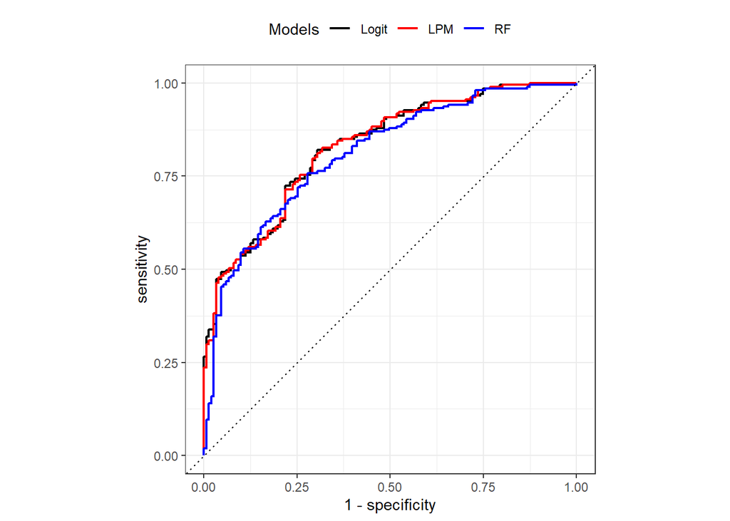

```r
# comparison: Logit v. LPM v. RF

roc_lpm %>%
    mutate(model="LPM") ->
    roc_lpm



roc_logit %>%
    mutate(model="Logit") ->
    roc_logit


roc_rf %>%
    mutate(model="RF") ->
    roc_rf

bind_m = bind_rows(roc_logit, roc_lpm, roc_rf)# binding three tibbles


bind_m %>%
  ggplot(aes(x = 1 - specificity, y = sensitivity, color = model)) +
  geom_path(linewidth = 0.8) +
  geom_abline(lty = 3) +
  coord_equal() +
  theme_bw() +
  scale_colour_manual(name="Models",values=c("Logit"="black", "LPM"="red","RF" = "blue")) +
  theme(legend.position = "top")
```

### Performance of the models with AUC

AUC is the area under the ROC curve.

```r
# LPM
auc_lpm = yardstick::roc_auc(preds_lpm,truth = high_traffic,prob_lpm,event_level = "second")
auc_lpm
```

| .metric | .estimator | .estimate |
| --- | --- | --- |
| roc_auc | binary | 0.8293822 |

```r
# Logit model
auc_logit = yardstick::roc_auc(preds_logit,truth = high_traffic,prob_logit,event_level = "second")
auc_logit
```

| .metric | .estimator | .estimate |
| --- | --- | --- |
| roc_auc | binary | 0.8300221 |

```r
# Logit model
auc_rf = yardstick::roc_auc(preds_rf,truth = high_traffic,prob_rf,event_level = "second")
auc_rf
```

| .metric | .estimator | .estimate |
| --- | --- | --- |
| roc_auc | binary | 0.8102185 |

Let ’s compare the AUC

```r
tibble(Metric="AUC" ,
       LPM = auc_lpm$.estimate,
       Logit= auc_logit$.estimate,
       RF = auc_rf$.estimate)
```

| Metric | LPM | Logit | RF |
| --- | --- | --- | --- |
| AUC | 0.8293822 | 0.8300221 | 0.8102185 |

### Preferred model

Reminding the proportion of the classes.

```r
data_traffic_recode_drop_na %>%
  count(high_traffic) %>%
  mutate(prop = n/sum(n))
```

| high_traffic | n | prop |
| --- | --- | --- |
| 0 | 360 | 0.4022346 |
| 1 | 535 | 0.5977654 |

The Logit model and the LPM have approximately the same accuracy score. However, since the class proportions are not equal, a model could achieve high accuracy simply by systematically predicting the majority class. The AUC-ROC metric allows us to compare models in terms of their ability to distinguish between classes. Therefore, we prefer the Logit model over the others because it has an AUC closest to 1.

## Preference model interpretation

The logistic model shows that food categories, particularly “Potato,” “Pork,” and “Lunch/Snacks,” are the best predictors of site traffic, while nutritional features such as calories or sugar have a limited impact. The overall performance of the model, measured by an accuracy of 0.7541899 and an AUC-ROC of 0.8300221, indicates that it is reliable and interpretable, clearly identifying the key factors influencing traffic. To increase traffic, it is recommended to create and promote more content around these three categories, optimize SEO for these categories, and adapt strategies based on seasonal trends or specific audience needs.Additionally, sharing these recipes on social media and collaborating with food influencers will boost visibility. Finally, personalized recommendations will encourage users to explore more content. These targeted actions should significantly contribute to increasing the website’s traffic.

## Session Information

```r
if (!require(sessioninfo)) install.packages("sessioninfo")

library(sessioninfo)
```

```r
platform_info()
```

```
##  setting  value
##  version  R version 4.4.1 (2024-06-14 ucrt)
##  os       Windows 11 x64 (build 22631)
##  system   x86_64, mingw32
##  ui       RTerm
##  language (EN)
##  collate  French_France.utf8
##  ctype    French_France.utf8
##  tz       Europe/Paris
##  date     2025-01-10
##  pandoc   3.2 @ C:/Program Files/RStudio/resources/app/bin/quarto/bin/tools/ (via rmarkdown)
```

```r
package_info(c("tidyverse", "ranger", "stargazer",
               "caret", "yardstick", "rpart", "rpart.plot", "mfx", "gridExtra"), dependencies=FALSE)
```